```python
# This Python 3 environment comes with many helpful analytics libraries installed
# It is defined by the kaggle/python Docker image: https://github.com/kaggle/docker-python
# For example, here's several helpful packages to load

import numpy as np # linear algebra
import pandas as pd # data processing, CSV file I/O (e.g. pd.read_csv)

# Input data files are available in the read-only "../input/" directory
# For example, running this (by clicking run or pressing Shift+Enter) will list all files under the input directory

import os
for dirname, _, filenames in os.walk('/kaggle/input'):
    for filename in filenames:
        print(os.path.join(dirname, filename))

# You can write up to 20GB to the current directory (/kaggle/working/) that gets preserved as output when you create a version using "Save & Run All"
# You can also write temporary files to /kaggle/temp/, but they won't be saved outside of the current session

import warnings # To suppress some warnings

# Suppress the specific FutureWarning
warnings.filterwarnings("ignore", category=FutureWarning, module="seaborn")

import matplotlib.pyplot as plt
import seaborn as sns

sns.set_style("whitegrid")
```

```
/kaggle/input/playground-series-s4e11/sample_submission.csv
/kaggle/input/playground-series-s4e11/train.csv
/kaggle/input/playground-series-s4e11/test.csv
```

# Introduction

`Time taken ⏱️`: ~5 hours

The dataset for this competition (both train and test) was generated from a deep learning model trained on the Depression Survey/Dataset for Analysis dataset. Feature distributions are close to, but not exactly the same, as the original. Feel free to use the original dataset as part of this competition, both to explore differences as well as to see whether incorporating the original in training improves model performance.

# Exploratory Data Analysis

```python
train_df = pd.read_csv("/kaggle/input/playground-series-s4e11/train.csv")
```

```python
train_df.sample(2).T
```

|  | 138815 | 12651 |
| --- | --- | --- |
| id | 138815 | 12651 |
| Name | Abhishek | Abhishek |
| Gender | Male | Male |
| Age | 20.0 | 33.0 |
| City | Hyderabad | Kolkata |
| Working Professional or Student | Student | Student |
| Profession | NaN | NaN |
| Academic Pressure | 2.0 | 5.0 |
| Work Pressure | NaN | NaN |
| CGPA | 7.25 | 7.92 |
| Study Satisfaction | 5.0 | 3.0 |
| Job Satisfaction | NaN | NaN |
| Sleep Duration | 5-6 hours | 5-6 hours |
| Dietary Habits | Healthy | Moderate |
| Degree | Class 12 | MSc |
| Have you ever had suicidal thoughts ? | Yes | Yes |
| Work/Study Hours | 6.0 | 11.0 |
| Financial Stress | 1.0 | 5.0 |
| Family History of Mental Illness | Yes | No |
| Depression | 0 | 1 |

```python
train_df.info()
```

```
<class 'pandas.core.frame.DataFrame'>
RangeIndex: 140700 entries, 0 to 140699
Data columns (total 20 columns):
 #   Column                                 Non-Null Count   Dtype
---  ------                                 --------------   -----
 0   id                                     140700 non-null  int64
 1   Name                                   140700 non-null  object
 2   Gender                                 140700 non-null  object
 3   Age                                    140700 non-null  float64
 4   City                                   140700 non-null  object
 5   Working Professional or Student        140700 non-null  object
 6   Profession                             104070 non-null  object
 7   Academic Pressure                      27897 non-null   float64
 8   Work Pressure                          112782 non-null  float64
 9   CGPA                                   27898 non-null   float64
 10  Study Satisfaction                     27897 non-null   float64
 11  Job Satisfaction                       112790 non-null  float64
 12  Sleep Duration                         140700 non-null  object
 13  Dietary Habits                         140696 non-null  object
 14  Degree                                 140698 non-null  object
 15  Have you ever had suicidal thoughts ?  140700 non-null  object
 16  Work/Study Hours                       140700 non-null  float64
 17  Financial Stress                       140696 non-null  float64
 18  Family History of Mental Illness       140700 non-null  object
 19  Depression                             140700 non-null  int64
dtypes: float64(8), int64(2), object(10)
memory usage: 21.5+ MB
```

```python
train_df.describe().T
```

|  | count | mean | std | min | 25% | 50% | 75% | max |
| --- | --- | --- | --- | --- | --- | --- | --- | --- |
| id | 140700.0 | 70349.500000 | 40616.735775 | 0.00 | 35174.75 | 70349.50 | 105524.25 | 140699.0 |
| Age | 140700.0 | 40.388621 | 12.384099 | 18.00 | 29.00 | 42.00 | 51.00 | 60.0 |
| Academic Pressure | 27897.0 | 3.142273 | 1.380457 | 1.00 | 2.00 | 3.00 | 4.00 | 5.0 |
| Work Pressure | 112782.0 | 2.998998 | 1.405771 | 1.00 | 2.00 | 3.00 | 4.00 | 5.0 |
| CGPA | 27898.0 | 7.658636 | 1.464466 | 5.03 | 6.29 | 7.77 | 8.92 | 10.0 |
| Study Satisfaction | 27897.0 | 2.944940 | 1.360197 | 1.00 | 2.00 | 3.00 | 4.00 | 5.0 |
| Job Satisfaction | 112790.0 | 2.974404 | 1.416078 | 1.00 | 2.00 | 3.00 | 4.00 | 5.0 |
| Work/Study Hours | 140700.0 | 6.252679 | 3.853615 | 0.00 | 3.00 | 6.00 | 10.00 | 12.0 |
| Financial Stress | 140696.0 | 2.988983 | 1.413633 | 1.00 | 2.00 | 3.00 | 4.00 | 5.0 |
| Depression | 140700.0 | 0.181713 | 0.385609 | 0.00 | 0.00 | 0.00 | 0.00 | 1.0 |

```python
train_df.isna().sum()
```

```
id                                            0
Name                                          0
Gender                                        0
Age                                           0
City                                          0
Working Professional or Student               0
Profession                                36630
Academic Pressure                        112803
Work Pressure                             27918
CGPA                                     112802
Study Satisfaction                       112803
Job Satisfaction                          27910
Sleep Duration                                0
Dietary Habits                                4
Degree                                        2
Have you ever had suicidal thoughts ?         0
Work/Study Hours                              0
Financial Stress                              4
Family History of Mental Illness              0
Depression                                    0
dtype: int64
```

## Distrbution of different categories

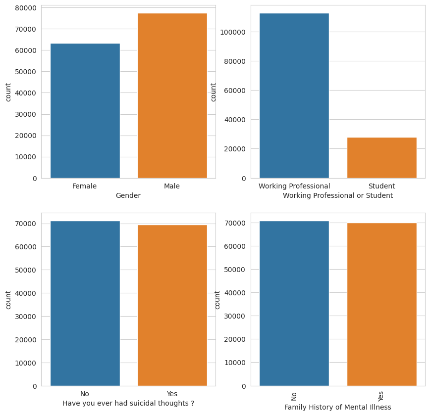

```python
fig, [[ax1, ax2],[ax3, ax4]] = plt.subplots(2,2, figsize=(10,10))

plt.xticks(rotation=90)
sns.countplot(train_df, x="Gender", ax=ax1)
sns.countplot(train_df, x="Working Professional or Student", ax=ax2)
sns.countplot(train_df, x="Have you ever had suicidal thoughts ?", ax=ax3)
sns.countplot(train_df, x="Family History of Mental Illness", ax=ax4)
```

## Huge Dimensions from the City and Profession columns

The categorical columns will be one hot encoded later, hence why the unique values are reffered to as dimensions.

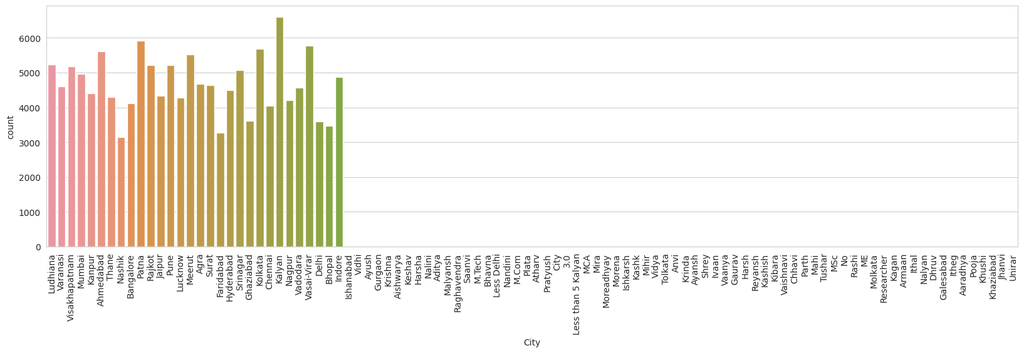

```python
fig, ax = plt.subplots(1,1, figsize=(20,5))

plt.xticks(rotation=90)
sns.countplot(train_df, x="City")
```

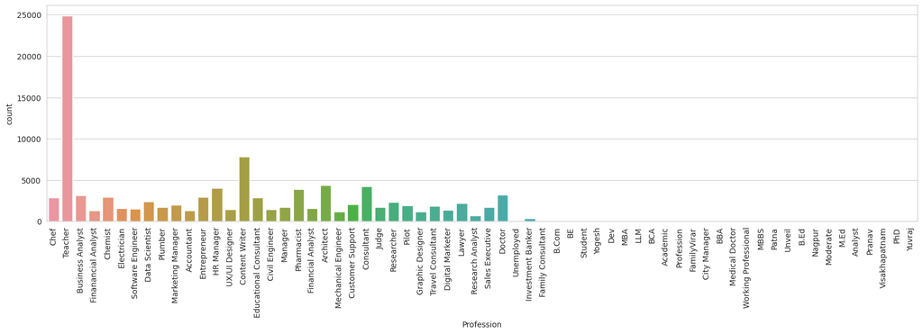

```python
fig, ax = plt.subplots(1,1, figsize=(20,5))

plt.xticks(rotation=90)
sns.countplot(train_df, x="Profession")
```

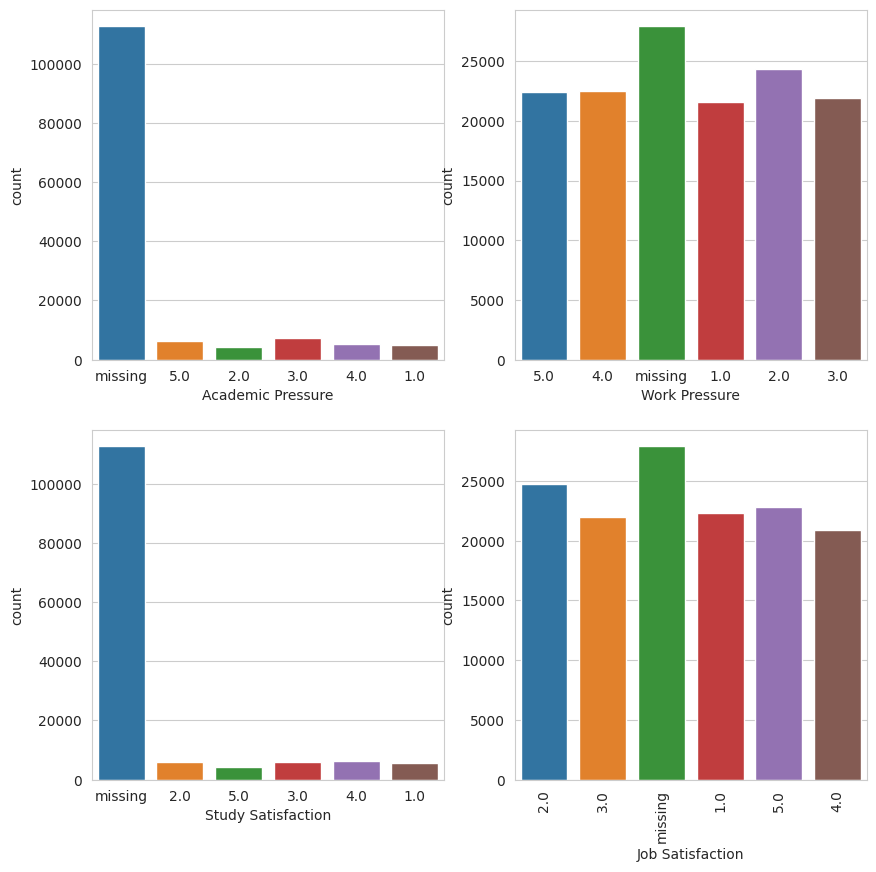

```python
fig, [[ax1, ax2],[ax3, ax4]] = plt.subplots(2,2, figsize=(10,10))

plt.xticks(rotation=90)
sns.countplot(train_df.fillna("missing"), x="Academic Pressure", ax=ax1)
sns.countplot(train_df.fillna("missing"), x="Work Pressure", ax=ax2)
sns.countplot(train_df.fillna("missing"), x="Study Satisfaction", ax=ax3)
sns.countplot(train_df.fillna("missing"), x="Job Satisfaction", ax=ax4)
```

## Why is there a huge amount of missing values for academic and work pressure ?

```python
# Students with work pressure
train_df[(train_df["Work Pressure"].notna()) & (train_df["Working Professional or Student"] == "Student")]
```

|  | id | Name | Gender | Age | City | Working Professional or Student | Profession | Academic Pressure | Work Pressure | CGPA | Study Satisfaction | Job Satisfaction | Sleep Duration | Dietary Habits | Degree | Have you ever had suicidal thoughts ? | Work/Study Hours | Financial Stress | Family History of Mental Illness | Depression |
| --- | --- | --- | --- | --- | --- | --- | --- | --- | --- | --- | --- | --- | --- | --- | --- | --- | --- | --- | --- | --- |
| 21880 | 21880 | Aarush | Male | 38.0 | Chennai | Student | NaN | NaN | 5.0 | NaN | NaN | 4.0 | 5-6 hours | Healthy | Class 12 | No | 2.0 | 3.0 | No | 0 |
| 75007 | 75007 | Aarav | Male | 21.0 | Lucknow | Student | NaN | NaN | 2.0 | NaN | NaN | 1.0 | 7-8 hours | Moderate | Class 12 | Yes | 3.0 | 3.0 | Yes | 0 |
| 129756 | 129756 | Kian | Male | 18.0 | Rajkot | Student | NaN | NaN | 5.0 | NaN | NaN | 4.0 | 7-8 hours | Moderate | Class 12 | Yes | 9.0 | 4.0 | No | 1 |

```python
# Workers with academic pressure
train_df[(train_df["Academic Pressure"].notna()) & (train_df["Working Professional or Student"] == "Working Professional")]
```

|  | id | Name | Gender | Age | City | Working Professional or Student | Profession | Academic Pressure | Work Pressure | CGPA | Study Satisfaction | Job Satisfaction | Sleep Duration | Dietary Habits | Degree | Have you ever had suicidal thoughts ? | Work/Study Hours | Financial Stress | Family History of Mental Illness | Depression |
| --- | --- | --- | --- | --- | --- | --- | --- | --- | --- | --- | --- | --- | --- | --- | --- | --- | --- | --- | --- | --- |
| 18752 | 18752 | Aarti | Female | 18.0 | Kalyan | Working Professional | NaN | 2.0 | NaN | 8.14 | 5.0 | NaN | Less than 5 hours | Healthy | Class 12 | Yes | 7.0 | 1.0 | Yes | 1 |
| 41915 | 41915 | Advait | Male | 18.0 | Kolkata | Working Professional | NaN | 4.0 | NaN | 8.04 | 3.0 | NaN | 5-6 hours | Healthy | Class 12 | Yes | 1.0 | 5.0 | Yes | 1 |
| 55827 | 55827 | Prachi | Female | 19.0 | Kalyan | Working Professional | NaN | 3.0 | NaN | 8.11 | 2.0 | NaN | 5-6 hours | Unhealthy | Class 12 | Yes | 4.0 | 4.0 | No | 1 |
| 99062 | 99062 | Tanisha | Female | 24.0 | Surat | Working Professional | Content Writer | 4.0 | NaN | 5.42 | 4.0 | NaN | Less than 5 hours | Moderate | B.Ed | Yes | 1.0 | 5.0 | No | 1 |
| 101189 | 101189 | Keshav | Male | 34.0 | Rajkot | Working Professional | NaN | 4.0 | NaN | 8.24 | 3.0 | NaN | More than 8 hours | Moderate | MD | No | 11.0 | 1.0 | No | 0 |

**Conclusion** There is negligible number of students with work pressure and negligible number of workers with academic pressure. So, I am going to merge the two columns in a single `pressure` column

```python
# If the row is a student, academic pressure takes precedence
# Else, work pressure take precedence
# If both are missing, then set as NaN

def merge_pressure(row):
    return row["Academic Pressure"] if row["Working Professional or Student"] == "Student" else row["Work Pressure"]

pressure_col = train_df.apply(merge_pressure, axis=1)
pressure_col = pd.Series(pressure_col, name="Work/Study Pressure")
```

```python
train_df = train_df.drop(["Academic Pressure","Work Pressure"], axis=1)
train_df = train_df.join(pressure_col)
```

```python
train_df["Work/Study Pressure"].isna().sum() # The remaining can be dropped since the dataset is huge
```

```
29
```

## Same things for study and work satisfaction

```python
# Students with job satisfaction
train_df[(train_df["Job Satisfaction"].notna()) & (train_df["Working Professional or Student"] == "Student")]
```

|  | id | Name | Gender | Age | City | Working Professional or Student | Profession | CGPA | Study Satisfaction | Job Satisfaction | Sleep Duration | Dietary Habits | Degree | Have you ever had suicidal thoughts ? | Work/Study Hours | Financial Stress | Family History of Mental Illness | Depression | Work/Study Pressure |
| --- | --- | --- | --- | --- | --- | --- | --- | --- | --- | --- | --- | --- | --- | --- | --- | --- | --- | --- | --- |
| 1428 | 1428 | Rishi | Male | 29.0 | Srinagar | Student | NaN | 9.63 | 3.0 | 3.0 | 7-8 hours | Moderate | M.Pharm | No | 8.0 | 5.0 | No | 0 | 3.0 |
| 21880 | 21880 | Aarush | Male | 38.0 | Chennai | Student | NaN | NaN | NaN | 4.0 | 5-6 hours | Healthy | Class 12 | No | 2.0 | 3.0 | No | 0 | NaN |
| 70453 | 70453 | Veda | Female | 20.0 | Ahmedabad | Student | NaN | NaN | NaN | 2.0 | Less than 5 hours | Moderate | Class 12 | Yes | 12.0 | 3.0 | Yes | 1 | NaN |
| 75007 | 75007 | Aarav | Male | 21.0 | Lucknow | Student | NaN | NaN | NaN | 1.0 | 7-8 hours | Moderate | Class 12 | Yes | 3.0 | 3.0 | Yes | 0 | NaN |
| 105773 | 105773 | Anand | Male | 18.0 | Ahmedabad | Student | NaN | NaN | NaN | 1.0 | Less than 5 hours | Moderate | Class 12 | Yes | 9.0 | 5.0 | No | 1 | NaN |
| 116703 | 116703 | Neil | Male | 25.0 | Bangalore | Student | NaN | 9.44 | 5.0 | 2.0 | Less than 5 hours | Unhealthy | PhD | Yes | 4.0 | 1.0 | No | 1 | 4.0 |
| 129756 | 129756 | Kian | Male | 18.0 | Rajkot | Student | NaN | NaN | NaN | 4.0 | 7-8 hours | Moderate | Class 12 | Yes | 9.0 | 4.0 | No | 1 | NaN |
| 134830 | 134830 | Aaradhya | Female | 24.0 | Meerut | Student | NaN | NaN | NaN | 2.0 | More than 8 hours | Unhealthy | Class 12 | No | 0.0 | 5.0 | No | 0 | NaN |

```python
# Workers with study satisfaction
train_df[(train_df["Study Satisfaction"].notna()) & (train_df["Working Professional or Student"] == "Working Professional")]
```

|  | id | Name | Gender | Age | City | Working Professional or Student | Profession | CGPA | Study Satisfaction | Job Satisfaction | Sleep Duration | Dietary Habits | Degree | Have you ever had suicidal thoughts ? | Work/Study Hours | Financial Stress | Family History of Mental Illness | Depression | Work/Study Pressure |
| --- | --- | --- | --- | --- | --- | --- | --- | --- | --- | --- | --- | --- | --- | --- | --- | --- | --- | --- | --- |
| 18752 | 18752 | Aarti | Female | 18.0 | Kalyan | Working Professional | NaN | 8.14 | 5.0 | NaN | Less than 5 hours | Healthy | Class 12 | Yes | 7.0 | 1.0 | Yes | 1 | NaN |
| 41915 | 41915 | Advait | Male | 18.0 | Kolkata | Working Professional | NaN | 8.04 | 3.0 | NaN | 5-6 hours | Healthy | Class 12 | Yes | 1.0 | 5.0 | Yes | 1 | NaN |
| 55827 | 55827 | Prachi | Female | 19.0 | Kalyan | Working Professional | NaN | 8.11 | 2.0 | NaN | 5-6 hours | Unhealthy | Class 12 | Yes | 4.0 | 4.0 | No | 1 | NaN |
| 60348 | 60348 | Nishant | Male | 29.0 | Agra | Working Professional | NaN | 9.72 | 2.0 | NaN | 5-6 hours | Moderate | B.Ed | No | 7.0 | 2.0 | Yes | 0 | NaN |
| 99062 | 99062 | Tanisha | Female | 24.0 | Surat | Working Professional | Content Writer | 5.42 | 4.0 | NaN | Less than 5 hours | Moderate | B.Ed | Yes | 1.0 | 5.0 | No | 1 | NaN |
| 101189 | 101189 | Keshav | Male | 34.0 | Rajkot | Working Professional | NaN | 8.24 | 3.0 | NaN | More than 8 hours | Moderate | MD | No | 11.0 | 1.0 | No | 0 | NaN |

```python
# If the row is a student, Study Satisfaction takes precedence
# Else, Job Satisfaction take precedence
# If both are missing, then set as NaN

def merge_satisfaction(row):
    return row["Study Satisfaction"] if row["Working Professional or Student"] == "Student" else row["Job Satisfaction"]

satisfaction_col = train_df.apply(merge_satisfaction, axis=1)
satisfaction_col = pd.Series(satisfaction_col, name="Job/Study Satisfaction")
```

```python
train_df = train_df.drop(["Study Satisfaction","Job Satisfaction"], axis=1)
train_df = train_df.join(satisfaction_col)
```

```python
train_df["Job/Study Satisfaction"].isna().sum() # The remaining can be dropped since the dataset is huge
```

```
27
```

Dropping rows with NA values for `Pressure` and `Financial Stress`, due to insignificant numbers

```python
train_df = train_df[train_df["Work/Study Pressure"].notna()]
train_df = train_df[train_df["Job/Study Satisfaction"].notna()]
train_df = train_df[train_df["Financial Stress"].notna()]
```

```python
train_df.sample(2)
```

|  | id | Name | Gender | Age | City | Working Professional or Student | Profession | CGPA | Sleep Duration | Dietary Habits | Degree | Have you ever had suicidal thoughts ? | Work/Study Hours | Financial Stress | Family History of Mental Illness | Depression | Work/Study Pressure | Job/Study Satisfaction |
| --- | --- | --- | --- | --- | --- | --- | --- | --- | --- | --- | --- | --- | --- | --- | --- | --- | --- | --- |
| 81178 | 81178 | Nandini | Female | 24.0 | Faridabad | Working Professional | Data Scientist | NaN | More than 8 hours | Moderate | B.Tech | No | 4.0 | 3.0 | No | 0 | 3.0 | 2.0 |
| 10710 | 10710 | Vibha | Female | 59.0 | Patna | Working Professional | Content Writer | NaN | Less than 5 hours | Moderate | B.Tech | Yes | 3.0 | 4.0 | Yes | 0 | 2.0 | 1.0 |

## Why drop 114 rows of data with unique professions ?

```python
train_df
```

|  | id | Name | Gender | Age | City | Working Professional or Student | Profession | CGPA | Sleep Duration | Dietary Habits | Degree | Have you ever had suicidal thoughts ? | Work/Study Hours | Financial Stress | Family History of Mental Illness | Depression | Work/Study Pressure | Job/Study Satisfaction |
| --- | --- | --- | --- | --- | --- | --- | --- | --- | --- | --- | --- | --- | --- | --- | --- | --- | --- | --- |
| 0 | 0 | Aaradhya | Female | 49.0 | Ludhiana | Working Professional | Chef | NaN | More than 8 hours | Healthy | BHM | No | 1.0 | 2.0 | No | 0 | 5.0 | 2.0 |
| 1 | 1 | Vivan | Male | 26.0 | Varanasi | Working Professional | Teacher | NaN | Less than 5 hours | Unhealthy | LLB | Yes | 7.0 | 3.0 | No | 1 | 4.0 | 3.0 |
| 2 | 2 | Yuvraj | Male | 33.0 | Visakhapatnam | Student | NaN | 8.97 | 5-6 hours | Healthy | B.Pharm | Yes | 3.0 | 1.0 | No | 1 | 5.0 | 2.0 |
| 3 | 3 | Yuvraj | Male | 22.0 | Mumbai | Working Professional | Teacher | NaN | Less than 5 hours | Moderate | BBA | Yes | 10.0 | 1.0 | Yes | 1 | 5.0 | 1.0 |
| 4 | 4 | Rhea | Female | 30.0 | Kanpur | Working Professional | Business Analyst | NaN | 5-6 hours | Unhealthy | BBA | Yes | 9.0 | 4.0 | Yes | 0 | 1.0 | 1.0 |
| ... | ... | ... | ... | ... | ... | ... | ... | ... | ... | ... | ... | ... | ... | ... | ... | ... | ... | ... |
| 140695 | 140695 | Vidya | Female | 18.0 | Ahmedabad | Working Professional | NaN | NaN | 5-6 hours | Unhealthy | Class 12 | No | 2.0 | 4.0 | Yes | 1 | 5.0 | 4.0 |
| 140696 | 140696 | Lata | Female | 41.0 | Hyderabad | Working Professional | Content Writer | NaN | 7-8 hours | Moderate | B.Tech | Yes | 6.0 | 5.0 | Yes | 0 | 5.0 | 4.0 |
| 140697 | 140697 | Aanchal | Female | 24.0 | Kolkata | Working Professional | Marketing Manager | NaN | More than 8 hours | Moderate | B.Com | No | 4.0 | 4.0 | No | 0 | 3.0 | 1.0 |
| 140698 | 140698 | Prachi | Female | 49.0 | Srinagar | Working Professional | Plumber | NaN | 5-6 hours | Moderate | ME | Yes | 10.0 | 1.0 | No | 0 | 5.0 | 2.0 |
| 140699 | 140699 | Sai | Male | 27.0 | Patna | Student | NaN | 9.24 | Less than 5 hours | Healthy | BCA | Yes | 2.0 | 3.0 | Yes | 1 | 4.0 | 1.0 |

140659 rows × 18 columns

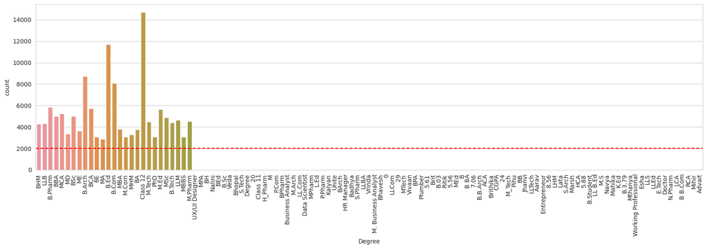

```python
plt.subplots(1,1, figsize=(20,5))

plt.xticks(rotation=90)
sns.countplot(train_df, x="Degree")
plt.axhline(y=2000, c="red", ls="--")
```

```python
(s := train_df["Degree"].value_counts())[s < 2000].sum()
```

```
114
```

**Conclusion** We are not going to use `LabelEncoder` for this column, since there is no ordinality between the categories. Instead, we are going to use `OneHotEncoder` to create dummy columns. However, doing so will introduce many dimensions, making the model training sub-optimal. Hence, we are going to remove the 114 rows with Degree value that has an insignificant frequency (<2000, indicated by the red dashed line), reducing the dimensions as a result.

```python
degree_val_counts = train_df["Degree"].value_counts()
insignificant_degree_col_values = degree_val_counts[degree_val_counts < 2000].keys()
insignificant_degree_col_values
```

```
Index(['M.Arch', 'UX/UI Designer', 'B.Sc', 'Kalyan', 'M', 'BArch', 'MEd',
       'BPharm', 'P.Com', 'Jhanvi', 'LLBA', 'Degree', 'B', 'Bhopal', 'BEd',
       'Nalini', 'LL B.Ed', 'L.Ed', '5.88', 'HCA', 'Marsh', 'S.Arch', 'Pihu',
       'Lata', 'LHM', '8.56', 'Entrepreneur', 'Aarav', 'LLTech', 'BB',
       'M_Tech', 'B.Student', 'E.Tech', 'M.S', 'Navya', 'Mihir', 'RCA',
       'B B.Com', 'LCA', 'N.Pharm', 'Doctor', 'CGPA', 'LLEd', 'LLS', 'Esha',
       'Working Professional', 'Mthanya', 'B.3.79', 'K.Ed', 'Mahika', '24',
       'Vrinda', 'Brithika', 'ACA', 'Badhya', 'HR Manager', 'Unite', 'P.Pharm',
       'MPharm', 'Data Scientist', 'LL.Com', 'Business Analyst', 'H_Pharm',
       'Class 11', '20', 'S.Tech', 'Veda', 'BH', 'MPA', 'S.Pharm',
       'M. Business Analyst', 'Bhavesh', 'Brit', 'B.B.Arch', '7.06', 'B BA',
       '5.56', 'Ritik', 'B.03', '5.61', '0', 'Plumber', 'BPA', 'Vivaan',
       'MTech', '29', 'LLCom', 'Advait'],
      dtype='object', name='Degree')
```

```python
train_df = train_df[~train_df["Degree"].isin(insignificant_degree_col_values)]
```

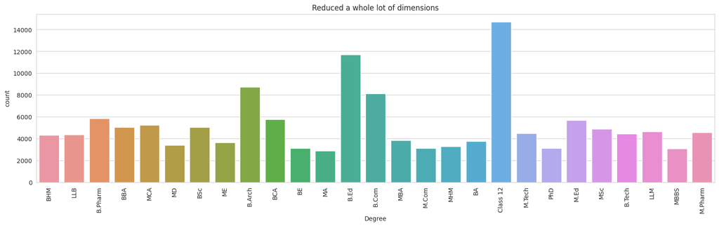

```python
plt.subplots(1,1, figsize=(20,5))

plt.xticks(rotation=90)
sns.countplot(train_df, x="Degree")
plt.title("Reduced a whole lot of dimensions")
```

## Relationships with target

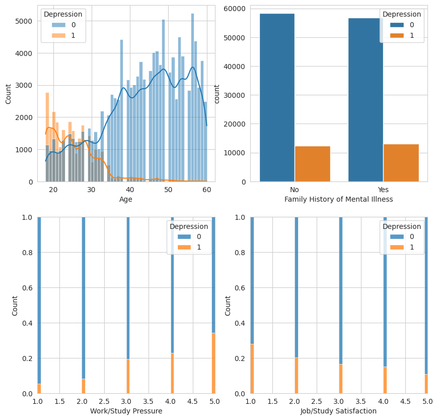

```python
fig, [[ax1, ax2],[ax3, ax4]] = plt.subplots(2,2, figsize=(10,10))

# plt.xticks(rotation=90)
sns.histplot(train_df, x="Age",kde=True, hue="Depression", ax=ax1)
sns.countplot(train_df, x="Family History of Mental Illness", hue="Depression", ax=ax2)
sns.histplot(train_df, x="Work/Study Pressure",multiple="fill", hue="Depression", ax=ax3)
sns.histplot(train_df, x="Job/Study Satisfaction",multiple="fill", hue="Depression", ax=ax4)
```

```python
train_df.sample(5)
```

|  | id | Name | Gender | Age | City | Working Professional or Student | Profession | CGPA | Sleep Duration | Dietary Habits | Degree | Have you ever had suicidal thoughts ? | Work/Study Hours | Financial Stress | Family History of Mental Illness | Depression | Work/Study Pressure | Job/Study Satisfaction |
| --- | --- | --- | --- | --- | --- | --- | --- | --- | --- | --- | --- | --- | --- | --- | --- | --- | --- | --- |
| 119395 | 119395 | Sanya | Male | 42.0 | Agra | Working Professional | Teacher | NaN | Less than 5 hours | Unhealthy | B.Ed | No | 10.0 | 4.0 | Yes | 0 | 1.0 | 2.0 |
| 85675 | 85675 | Ishaani | Female | 42.0 | Ghaziabad | Working Professional | Consultant | NaN | 7-8 hours | Moderate | BBA | No | 4.0 | 1.0 | No | 0 | 5.0 | 2.0 |
| 129275 | 129275 | Yuvraj | Male | 43.0 | Ahmedabad | Working Professional | Yuvraj | NaN | 7-8 hours | Moderate | MSc | No | 3.0 | 1.0 | No | 0 | 3.0 | 3.0 |
| 20132 | 20132 | Chirag | Male | 57.0 | Rajkot | Working Professional | Chef | NaN | 7-8 hours | Unhealthy | BHM | No | 7.0 | 4.0 | No | 0 | 4.0 | 3.0 |
| 6370 | 6370 | Raunak | Male | 21.0 | Kalyan | Working Professional | Teacher | NaN | 5-6 hours | Moderate | BCA | No | 12.0 | 2.0 | Yes | 0 | 4.0 | 3.0 |

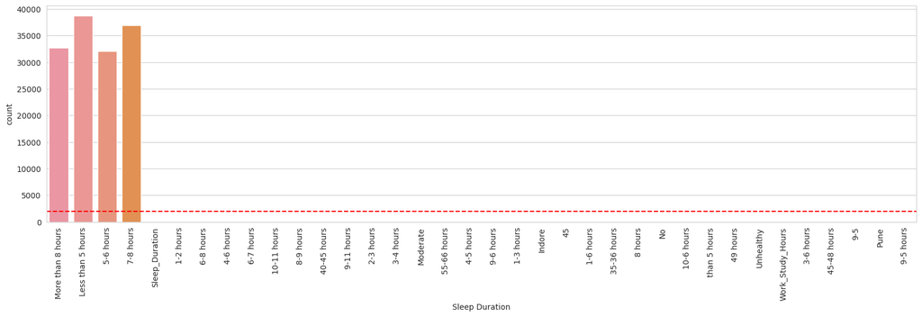

```python
plt.subplots(1,1, figsize=(20,5))

plt.xticks(rotation=90)
sns.countplot(train_df, x="Sleep Duration")
plt.axhline(y=2000, c="red", ls="--")
```

```python
# Just removing the values that have insignificant frequencies
sleep_duration_val_counts = train_df["Sleep Duration"].value_counts()
insignificant_sleep_duration_col_values = sleep_duration_val_counts[sleep_duration_val_counts < 2000].keys()
insignificant_sleep_duration_col_values
```

```
Index(['3-4 hours', '6-7 hours', '4-5 hours', '2-3 hours', '4-6 hours',
       '6-8 hours', '1-6 hours', 'No', '9-11 hours', '10-11 hours',
       'Sleep_Duration', 'Unhealthy', '45', '8-9 hours', '10-6 hours', '9-5',
       '45-48 hours', '3-6 hours', 'Work_Study_Hours', '49 hours',
       'than 5 hours', 'Pune', '9-6 hours', '8 hours', '35-36 hours', 'Indore',
       '1-3 hours', '55-66 hours', 'Moderate', '40-45 hours', '1-2 hours',
       '9-5 hours'],
      dtype='object', name='Sleep Duration')
```

```python
train_df = train_df[~train_df["Sleep Duration"].isin(insignificant_sleep_duration_col_values)]
```

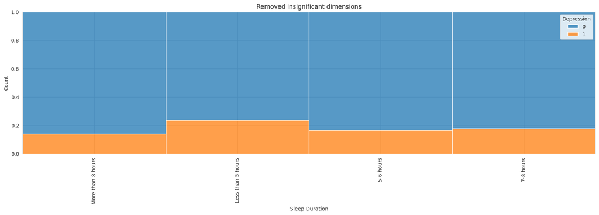

```python
plt.subplots(1,1, figsize=(20,5))

plt.xticks(rotation=90)
sns.histplot(train_df, x="Sleep Duration", hue="Depression", multiple="fill")
plt.title("Removed insignificant dimensions")
```

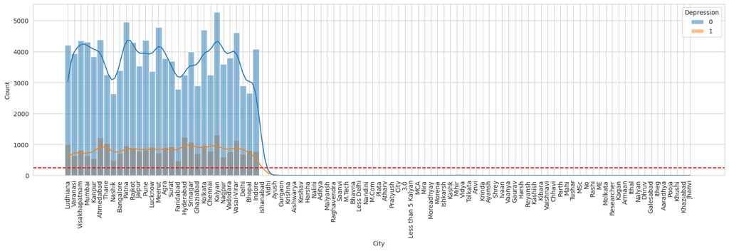

```python
plt.subplots(1,1, figsize=(20,5))

plt.xticks(rotation=90)
sns.histplot(train_df, x="City", hue="Depression", kde=True)
plt.axhline(y=250, c="red", ls="--")
```

```python
# Just removing the values that have insignificant frequencies
city_val_counts = train_df["City"].value_counts()
insignificant_city_col_values = city_val_counts[city_val_counts < 2000].keys()
insignificant_city_col_values
```

```
Index(['Mihir', 'Nandini', 'Saanvi', 'City', 'Pratyush', 'Harsha', 'Bhavna',
       'Mahi', 'Vidya', 'MCA', 'Atharv', 'M.Com', 'Molkata', 'Nalini',
       'Keshav', 'Ayush', 'Tushar', 'MSc', 'Parth', 'Chhavi', 'Vaishnavi',
       'Kibara', 'No', 'Rashi', 'Kashish', 'ME', 'Itheg', 'Researcher',
       'Kagan', 'Armaan', 'Ithal', 'Nalyan', 'Dhruv', 'Galesabad', 'Harsh',
       'Aaradhya', 'Pooja', 'Khushi', 'Khaziabad', 'Reyansh', 'Plata',
       'Gaurav', 'Vaanya', 'Ishanabad', 'Vidhi', 'Gurgaon', 'Krishna',
       'Aishwarya', 'Aditya', 'Malyansh', 'Raghavendra', 'M.Tech',
       'Less Delhi', '3.0', 'Less than 5 Kalyan', 'Mira', 'Moreadhyay',
       'Morena', 'Ishkarsh', 'Kashk', 'Tolkata', 'Anvi', 'Krinda', 'Ayansh',
       'Shrey', 'Ivaan', 'Jhanvi'],
      dtype='object', name='City')
```

```python
train_df = train_df[~train_df["City"].isin(insignificant_city_col_values)] # 97 rows
```

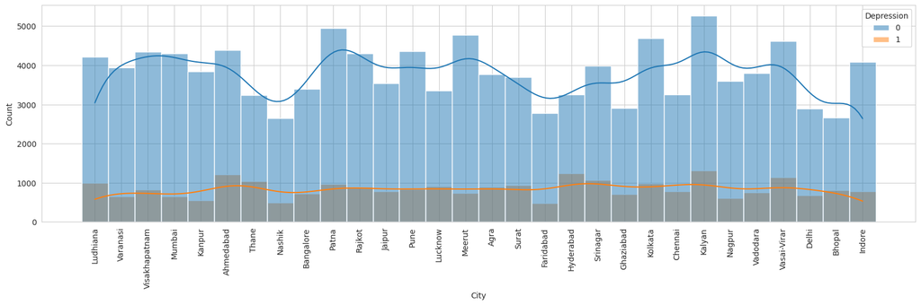

```python
plt.subplots(1,1, figsize=(20,5))

plt.xticks(rotation=90)
sns.histplot(train_df, x="City", hue="Depression", kde=True)
```

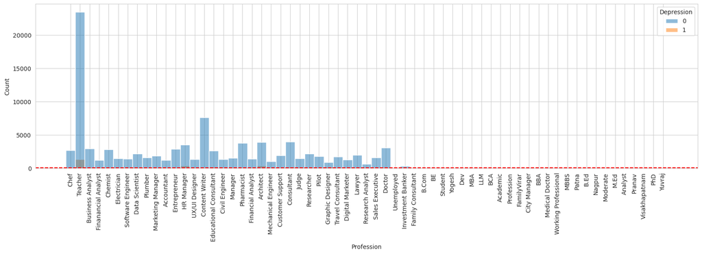

```python
plt.subplots(1,1, figsize=(20,5))

plt.xticks(rotation=90)
sns.histplot(train_df, x="Profession", hue="Depression")
plt.axhline(y=100, c="red", ls="--")
```

```python
# Just removing the values that have insignificant frequencies
profession_val_counts = train_df["Profession"].value_counts()
insignificant_profession_col_values = profession_val_counts[profession_val_counts < 100].keys()
insignificant_profession_col_values
```

```
Index(['Student', 'Academic', 'Unemployed', 'Profession', 'Yogesh', 'BCA',
       'MBA', 'LLM', 'PhD', 'Patna', 'Analyst', 'Pranav', 'Visakhapatnam',
       'M.Ed', 'Moderate', 'Nagpur', 'B.Ed', 'City Manager', 'MBBS',
       'Working Professional', 'Medical Doctor', 'BBA', 'FamilyVirar', 'Dev',
       'BE', 'B.Com', 'Family Consultant', 'Yuvraj'],
      dtype='object', name='Profession')
```

```python
train_df = train_df[~train_df["Profession"].isin(insignificant_profession_col_values)] # 49 rows
```

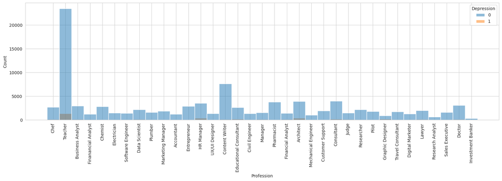

```python
plt.subplots(1,1, figsize=(20,5))

plt.xticks(rotation=90)
sns.histplot(train_df, x="Profession", hue="Depression")
```

```python
def assign_student_if_student(row):
    return "Student" if row["Working Professional or Student"] == "Student" else row["Profession"]

train_df["Profession"] = train_df.apply(assign_student_if_student, axis=1)
```

```python
# Fill the remaining values as Unknown
train_df = train_df.fillna({
    "Profession": "Unknown"
})
```

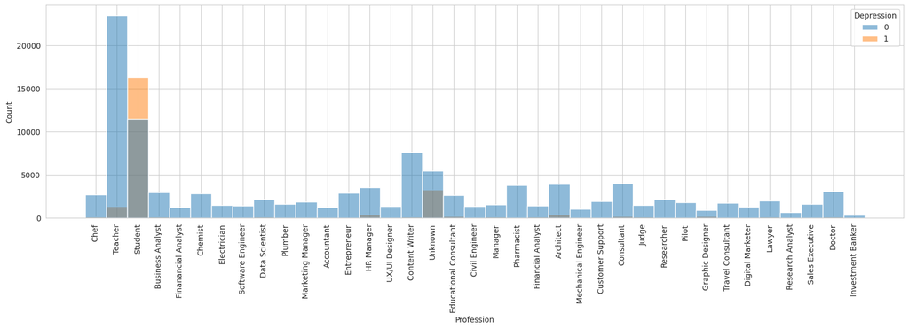

```python
plt.subplots(1,1, figsize=(20,5))

plt.xticks(rotation=90)
sns.histplot(train_df, x="Profession", hue="Depression")
```

```python
train_df.sample(3)
```

|  | id | Name | Gender | Age | City | Working Professional or Student | Profession | CGPA | Sleep Duration | Dietary Habits | Degree | Have you ever had suicidal thoughts ? | Work/Study Hours | Financial Stress | Family History of Mental Illness | Depression | Work/Study Pressure | Job/Study Satisfaction |
| --- | --- | --- | --- | --- | --- | --- | --- | --- | --- | --- | --- | --- | --- | --- | --- | --- | --- | --- |
| 119917 | 119917 | Ila | Female | 39.0 | Lucknow | Working Professional | Chef | NaN | More than 8 hours | Healthy | MHM | Yes | 2.0 | 2.0 | Yes | 0 | 2.0 | 4.0 |
| 72221 | 72221 | Ritika | Female | 28.0 | Nashik | Student | Student | 9.46 | Less than 5 hours | Healthy | MBBS | No | 11.0 | 4.0 | Yes | 1 | 2.0 | 4.0 |
| 119829 | 119829 | Ishwar | Male | 31.0 | Delhi | Working Professional | Lawyer | NaN | 7-8 hours | Unhealthy | LLB | Yes | 9.0 | 3.0 | Yes | 1 | 4.0 | 2.0 |

# Preprocessing

```python
y = train_df["Depression"]
X = train_df.drop(["id","Name","CGPA","Depression"], axis=1) # Dropping CGPA because I don't have time for it

X[:3]
```

|  | Gender | Age | City | Working Professional or Student | Profession | Sleep Duration | Dietary Habits | Degree | Have you ever had suicidal thoughts ? | Work/Study Hours | Financial Stress | Family History of Mental Illness | Work/Study Pressure | Job/Study Satisfaction |
| --- | --- | --- | --- | --- | --- | --- | --- | --- | --- | --- | --- | --- | --- | --- |
| 0 | Female | 49.0 | Ludhiana | Working Professional | Chef | More than 8 hours | Healthy | BHM | No | 1.0 | 2.0 | No | 5.0 | 2.0 |
| 1 | Male | 26.0 | Varanasi | Working Professional | Teacher | Less than 5 hours | Unhealthy | LLB | Yes | 7.0 | 3.0 | No | 4.0 | 3.0 |
| 2 | Male | 33.0 | Visakhapatnam | Student | Student | 5-6 hours | Healthy | B.Pharm | Yes | 3.0 | 1.0 | No | 5.0 | 2.0 |

```python
from sklearn.compose import ColumnTransformer
from sklearn.preprocessing import StandardScaler, OneHotEncoder
```

```python
X.columns
```

```
Index(['Gender', 'Age', 'City', 'Working Professional or Student',
       'Profession', 'Sleep Duration', 'Dietary Habits', 'Degree',
       'Have you ever had suicidal thoughts ?', 'Work/Study Hours',
       'Financial Stress', 'Family History of Mental Illness',
       'Work/Study Pressure', 'Job/Study Satisfaction'],
      dtype='object')
```

```python
cat_columns = ["Gender","City","Working Professional or Student","Profession","Sleep Duration","Dietary Habits","Degree","Have you ever had suicidal thoughts ?","Family History of Mental Illness"]
num_columns = list(set(X.columns) - set(cat_columns))
```

```python
preprocessor = ColumnTransformer([
    ("cat", OneHotEncoder(drop="first", handle_unknown="ignore"), cat_columns),
    ("num", StandardScaler(), num_columns)
])
```

```python
from sklearn.model_selection import train_test_split

X_train, X_test, y_train, y_test = train_test_split(X, y, test_size=0.15, random_state=42)
```

```python
preprocessor = preprocessor.fit(X_train)
X_train = preprocessor.transform(X_train)
X_test = preprocessor.transform(X_test)
```

# Training

```python
from sklearn.linear_model import LogisticRegression
```

```python
from sklearn.metrics import accuracy_score, precision_score, f1_score, recall_score, confusion_matrix

# Evaluating
error_dfs = []
def train_and_generate_error(model):
    model.fit(X_train, y_train)
    y_pred = model.predict(X_test)

    acc = accuracy_score(y_test, y_pred)
    precision = precision_score(y_test, y_pred)
    f1 = f1_score(y_test, y_pred)
    recall = recall_score(y_test, y_pred)

    error_df = pd.DataFrame([], columns=["Error Name","Error Value","Error Range"])

    def generate_error_row(error_name: str, err_val: float, range: str):
        error_df.loc[len(error_df)] = [error_name, err_val, range]

    generate_error_row("Accuracy", acc, "[0, 1]")
    generate_error_row("Precision", precision, "[0, 1]")
    generate_error_row("F1 score", f1, "[0, 1]")
    generate_error_row("Recall", recall, "[0, 1]")

    error_dfs.append(error_df)

    return model
```

```python
error_dfs = []

reg_model = train_and_generate_error(LogisticRegression(max_iter=500))
```

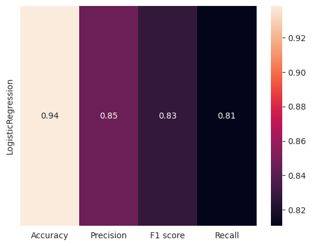

```python
# Heatmapping errors on different models
model_names = ["LogisticRegression"]
error_values = {model_names[i] : list(map(lambda err: err[1], mdl.values)) for i, mdl in enumerate(error_dfs)}

model_error_df = pd.DataFrame(error_values, index=["Accuracy","Precision","F1 score","Recall"]).T
sns.heatmap(model_error_df, annot=True)
```